# Forecasting & Time Series Methods Homework 4

By Apoorv Shrivastava

### Step 1: Load the required packages and import the data set

*First, we will load the required packages. Once the packages are loaded, we will import the data in R as time series*

```r
### Calling Libraries
library(tidyverse)
library(tseries)
library(TSA)
library(lmtest)
library(forecast)
```

```r
### Importing the Data
data_ts<-ts(scan('C:/Users/appus/Downloads/MSBANA Course/Time Series Forecasting/hw/Disposable_Income.csv'), start=c(1961,1), end=c(1987,4), frequency=4)
data_ts
```

```
##         Qtr1    Qtr2    Qtr3    Qtr4
## 1961  94.762 105.198 119.893 155.660
## 1962 101.572 114.884 129.024 164.349
## 1963 105.877 125.020 137.605 181.924
## 1964 122.895 139.527 153.183 196.361
## 1965 132.268 147.687 162.387 207.320
## 1966 139.799 163.715 179.276 227.159
## 1967 151.526 179.374 189.352 256.129
## 1968 178.552 196.426 214.842 282.166
## 1969 187.868 218.758 238.740 319.899
## 1970 205.115 240.570 262.950 337.889
## 1971 233.299 254.147 277.139 346.586
## 1972 242.428 278.194 301.307 397.574
## 1973 271.102 307.345 344.307 443.664
## 1974 268.901 338.393 361.424 441.264
## 1975 294.389 346.107 367.151 463.097
## 1976 313.357 365.749 374.090 478.154
## 1977 317.604 373.722 382.937 492.229
## 1978 334.981 396.280 390.168 510.905
## 1979 341.405 412.983 407.038 517.548
## 1980 340.266 424.350 409.859 520.987
## 1981 348.314 435.411 413.441 528.965
## 1982 355.327 440.832 423.578 542.004
## 1983 362.008 460.790 440.726 549.568
## 1984 372.675 469.322 450.183 562.904
## 1985 382.887 486.589 459.198 575.308
## 1986 397.173 501.300 478.004 597.556
## 1987 412.666 508.603 488.534 617.406
```

### Step 2: Model Estimation

*After importing the dataset, we need to plot the time series data and its ACF PACF. This will help us to have an idea about the time series data and answer the following questions:*

- *The Time Series is stationary or not?*
- *Does the Times Series have constant mean ?*
- *Is there a stochastic or deterministic trend in the data*

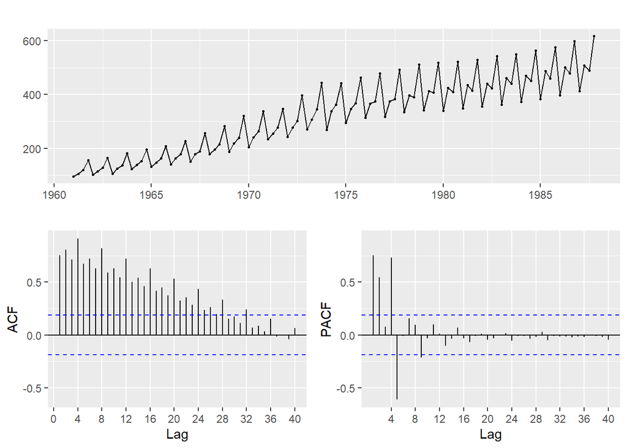

```r
### Plot the time series
data_ts %>% ggtsdisplay(lag.max = 40)
```

*From the time series and its ACF plot we feel that the time series is not stationary and includes seasonality as well as trend. Additionally, we don’t have as constant variance.*

### Step 3: Stabilizing Non-Constant Variance

*To stabilize the variance, we will do BoxCox Power Transformation and check the plot again to confirm whether the variance is stabilized or not. (The Lambda value indicates the power to which all data should be raised)*

```r
### Try to stabilize the variance
bc <- BoxCox.ar(data_ts)
```

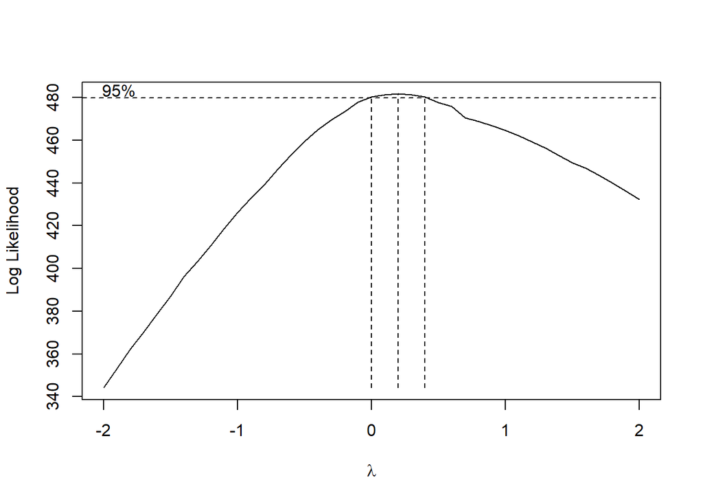

```r
bc$lambda[which.max(bc$loglike)]
```

```
## [1] 0.2
```

*Visual check finds the variance increases as time goes by, therefore, we use box-cox transformation with lambda=0, i.e., log transformation.*

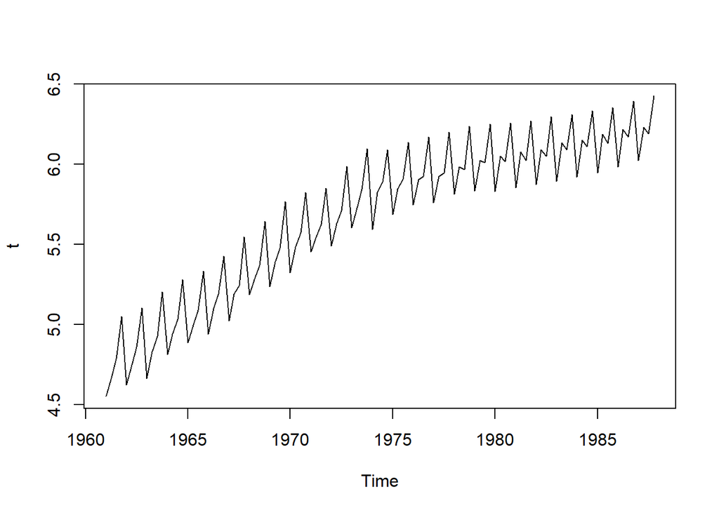

```r
### Boxcox Transformation
t<-log(data_ts)
plot(t)
```

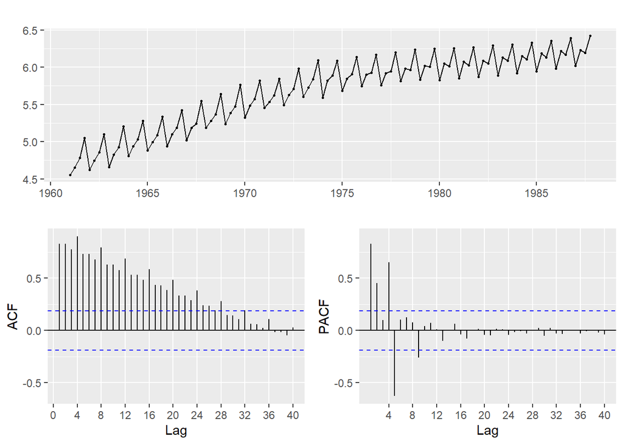

```r
### Trying to capture seasonality
data_ts %>% log() %>% ggtsdisplay(lag.max = 40)
```

*The ACF at lags 4, 8, 12 are still decreasing slowly.We need to check for seasonality.*

### Step 4: Seasonality check

*To capture the seasonality, we will take first order difference of the series and check the plot again to confirm whether we have seasonality or not.*

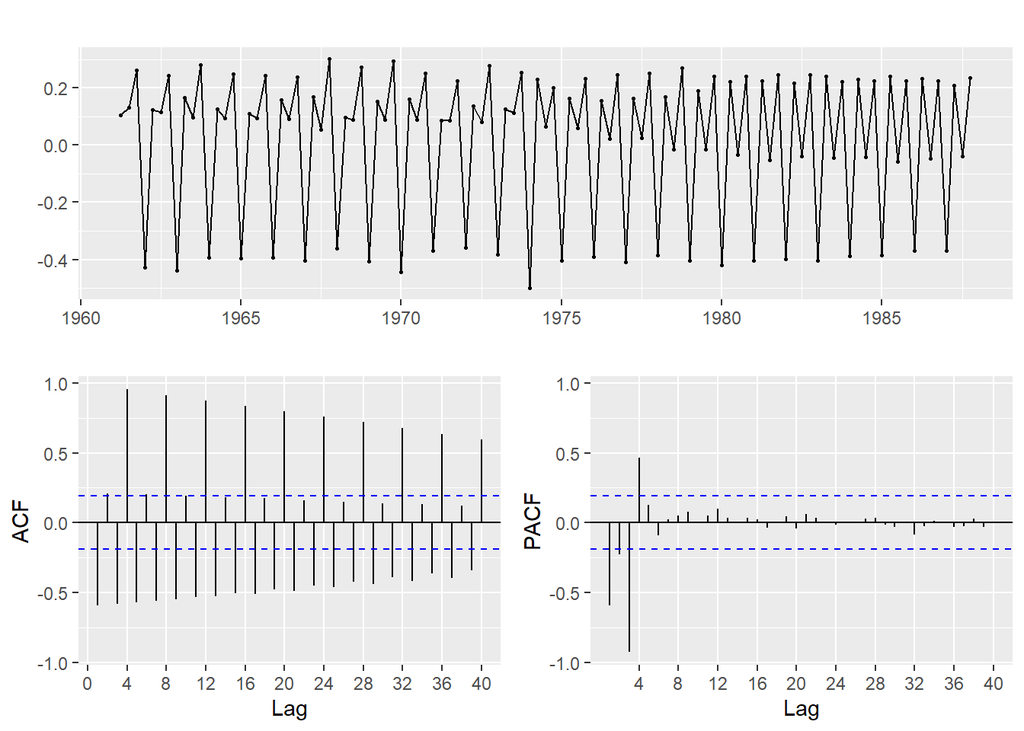

```r
data_ts %>% log() %>% diff() %>% ggtsdisplay(lag.max = 40)
```

### Step 5: Stationarity Test

```r
### Determining stationarity
data_ts %>% log %>% diff() %>% adf.test()
```

```
##
##  Augmented Dickey-Fuller Test
##
## data:  .
## Dickey-Fuller = -4.6074, Lag order = 4, p-value = 0.01
## alternative hypothesis: stationary
```

### Step 6: Parameter Estimation and Residual Analysis

```r
(fit <- Arima(data_ts, order=c(0,0,1), seasonal=c(0,1,1),include.constant = FALSE,lambda=0))
```

```
## Series: data_ts
## ARIMA(0,0,1)(0,1,1)[4]
## Box Cox transformation: lambda= 0
##
## Coefficients:
##          ma1    sma1
##       0.8435  0.3471
## s.e.  0.0649  0.0775
##
## sigma^2 estimated as 0.001796:  log likelihood=181.5
## AIC=-357   AICc=-356.76   BIC=-349.07
```

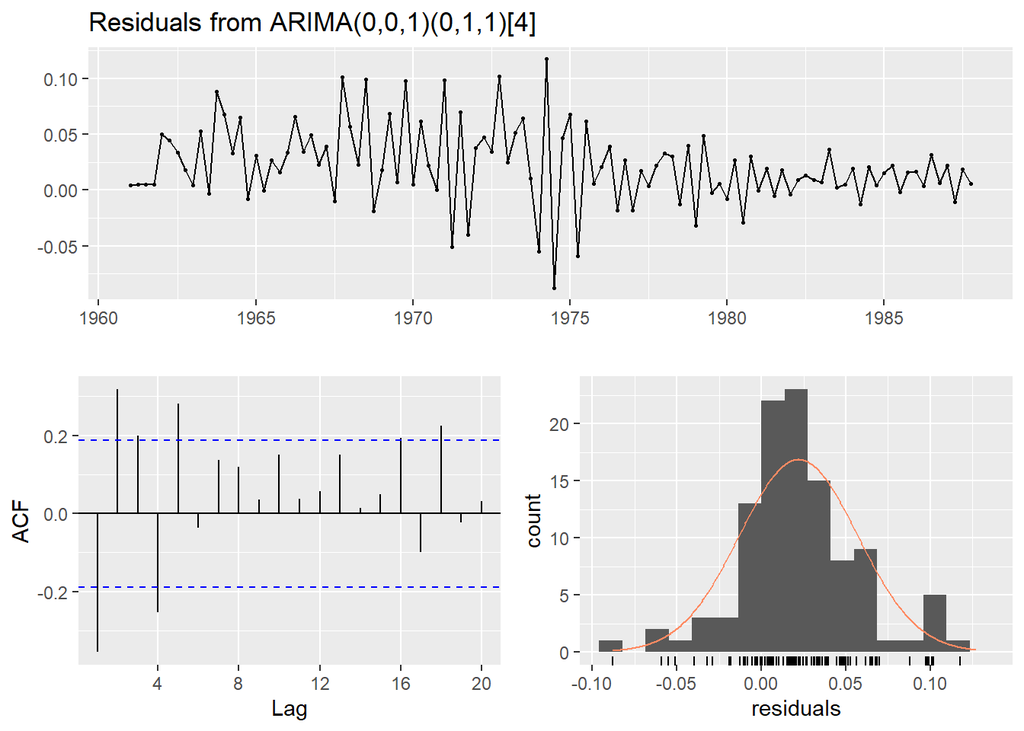

```
##
##  Ljung-Box test
##
## data:  Residuals from ARIMA(0,0,1)(0,1,1)[4]
## Q* = 50.285, df = 6, p-value = 4.121e-09
##
## Model df: 2.   Total lags used: 8
```

```r
checkresiduals(fit)
```

*In the residuals, we can see significant spikes at lag 1,2, 4, and so on. So, disregarding this model.*

```r
(fit1 <- Arima(data_ts, order=c(0,0,2), seasonal=c(0,1,1),include.constant = FALSE,lambda=0))
```

```
## Series: data_ts
## ARIMA(0,0,2)(0,1,1)[4]
## Box Cox transformation: lambda= 0
##
## Coefficients:
##          ma1    ma2    sma1
##       0.0683  0.819  0.5118
## s.e.  0.0706  0.052  0.0794
##
## sigma^2 estimated as 0.001501:  log likelihood=190.94
## AIC=-373.88   AICc=-373.47   BIC=-363.3
```

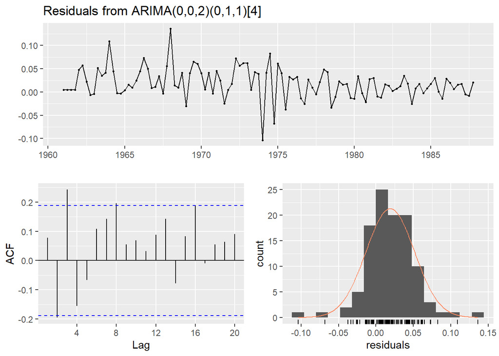

```
##
##  Ljung-Box test
##
## data:  Residuals from ARIMA(0,0,2)(0,1,1)[4]
## Q* = 23.192, df = 5, p-value = 0.0003103
##
## Model df: 3.   Total lags used: 8
```

```r
checkresiduals(fit1)
```

*In the residuals, we can still see significant spikes.So, disregarding this model as well.*

```r
(fit2 <- Arima(data_ts, order=c(0,0,3), seasonal=c(0,1,1),include.constant = FALSE,lambda=0))
```

```
## Series: data_ts
## ARIMA(0,0,3)(0,1,1)[4]
## Box Cox transformation: lambda= 0
##
## Coefficients:
##          ma1     ma2     ma3    sma1
##       0.7089  0.6650  0.7844  0.3877
## s.e.  0.0668  0.0765  0.0556  0.0836
##
## sigma^2 estimated as 0.0009414:  log likelihood=215.65
## AIC=-421.3   AICc=-420.69   BIC=-408.08
```

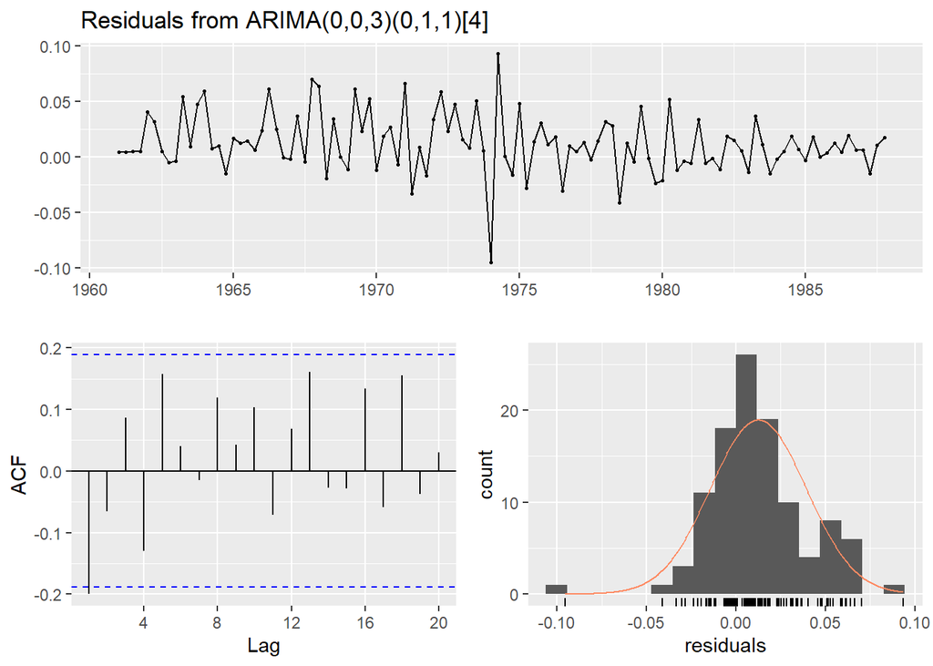

```
##
##  Ljung-Box test
##
## data:  Residuals from ARIMA(0,0,3)(0,1,1)[4]
## Q* = 12.414, df = 4, p-value = 0.01453
##
## Model df: 4.   Total lags used: 8
```

```r
checkresiduals(fit2)
```

*We see significant spikes in the ACF, let’s modify our model a bit.*

```r
(fit3 <- Arima(data_ts, order=c(1,0,1), seasonal=c(0,1,1),include.constant = FALSE,lambda=0))
```

```
## Series: data_ts
## ARIMA(1,0,1)(0,1,1)[4]
## Box Cox transformation: lambda= 0
##
## Coefficients:
##          ar1      ma1     sma1
##       0.9965  -0.5996  -0.4939
## s.e.  0.0047   0.0798   0.0820
##
## sigma^2 estimated as 0.0006535:  log likelihood=233.61
## AIC=-459.21   AICc=-458.81   BIC=-448.63
```

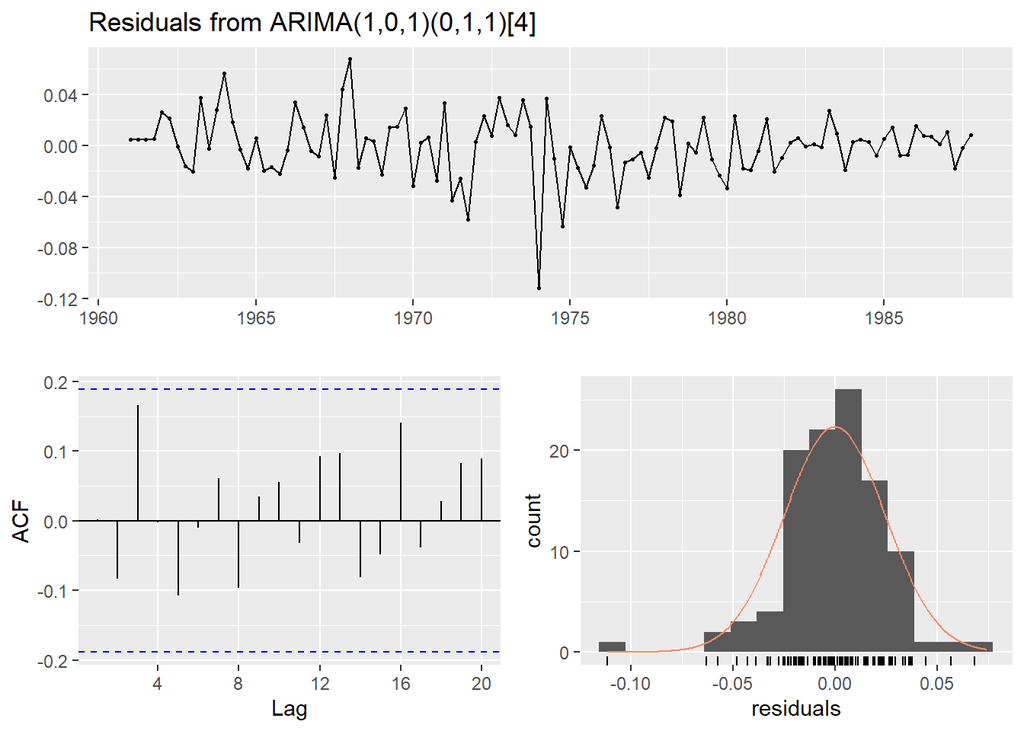

```
##
##  Ljung-Box test
##
## data:  Residuals from ARIMA(1,0,1)(0,1,1)[4]
## Q* = 6.8214, df = 5, p-value = 0.2343
##
## Model df: 3.   Total lags used: 8
```

```r
checkresiduals(fit3)
```

*The AIC and BIC of ARIMA(1,0,1)(0,1,1)[4] model is less and residual looks good.Let’s check for overfitting before deciding on the model.*

### Step 7: Check for Overfitting

```r
(fit4 <-Arima(data_ts, order=c(1,0,2), seasonal=c(0,1,1),include.constant = FALSE,lambda=0))
```

```
## Series: data_ts
## ARIMA(1,0,2)(0,1,1)[4]
## Box Cox transformation: lambda= 0
##
## Coefficients:
##          ar1      ma1     ma2     sma1
##       0.9963  -0.6053  0.0097  -0.4947
## s.e.  0.0048   0.1106  0.1249   0.0828
##
## sigma^2 estimated as 0.0006601:  log likelihood=233.61
## AIC=-457.22   AICc=-456.6   BIC=-443.99
```

```r
coeftest(fit4)
```

```
##
## z test of coefficients:
##
##        Estimate Std. Error  z value  Pr(>|z|)
## ar1   0.9963464  0.0047915 207.9411 < 2.2e-16 ***
## ma1  -0.6053034  0.1106141  -5.4722 4.445e-08 ***
## ma2   0.0096698  0.1249494   0.0774    0.9383
## sma1 -0.4946993  0.0828374  -5.9719 2.345e-09 ***
## ---
## Signif. codes:  0 '***' 0.001 '**' 0.01 '*' 0.05 '.' 0.1 ' ' 1
```

```r
(fit5 <-Arima(data_ts, order=c(2,0,1), seasonal=c(0,1,1),include.constant = FALSE,lambda=0))
```

```
## Series: data_ts
## ARIMA(2,0,1)(0,1,1)[4]
## Box Cox transformation: lambda= 0
##
## Coefficients:
##          ar1     ar2      ma1     sma1
##       0.9871  0.0092  -0.5935  -0.4941
## s.e.  0.1583  0.1571   0.1282   0.0824
##
## sigma^2 estimated as 0.0006601:  log likelihood=233.61
## AIC=-457.21   AICc=-456.6   BIC=-443.99
```

```r
coeftest(fit5)
```

```
##
## z test of coefficients:
##
##       Estimate Std. Error z value  Pr(>|z|)
## ar1   0.987132   0.158268  6.2371 4.458e-10 ***
## ar2   0.009194   0.157122  0.0585    0.9533
## ma1  -0.593527   0.128194 -4.6299 3.658e-06 ***
## sma1 -0.494140   0.082421 -5.9953 2.031e-09 ***
## ---
## Signif. codes:  0 '***' 0.001 '**' 0.01 '*' 0.05 '.' 0.1 ' ' 1
```

*The higher coefficients of of both the models are insignificant and existing coefficients do not changed significantly. So, based on AIC and BIC, we are sticking with ARIMA(1,0,1)(0,1,1)[4] model.*

### Step 8: Forecasting

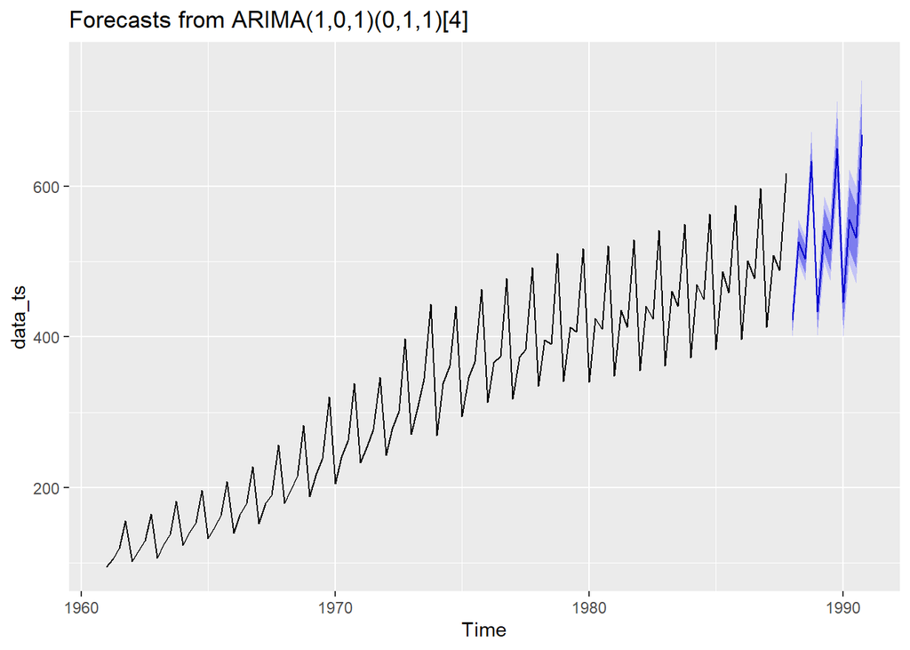

```r
fit3 %>% forecast(h=12) %>% autoplot()
```

*When we can compare the model with auto.arima, it suggested a slightly different model.*

```r
auto.arima(log(data_ts))
```

```
## Series: log(data_ts)
## ARIMA(0,1,1)(0,1,1)[4]
##
## Coefficients:
##           ma1     sma1
##       -0.6016  -0.4962
## s.e.   0.0792   0.0814
##
## sigma^2 estimated as 0.0006488:  log likelihood=232.12
## AIC=-458.24   AICc=-458   BIC=-450.34
```